# Retirement Income Toolkit - Economic Scenario - VAR

Queenie Huang

```r
library(tidyverse)
library(ggplot2)
library(gridExtra)
library(readxl)
library(janitor)
library(lubridate)
library(vars)
library(tseries)
library(corrplot)
library(kableExtra)
library(reshape2)
library(latex2exp)
library(aTSA)
library(caret)
library(Metrics)
```

A VAR(p) process can be represented by
$$\begin{align*}
\boldsymbol{Y}_t = \boldsymbol{\alpha }+ A_1 \boldsymbol{Y}_{t-1} + \ldots + A_p \boldsymbol{Y}_{t-p} + \boldsymbol{\epsilon},
\end{align*}$$
where $n$ is the number of economic/financial variables, $p$ is the lag, $\boldsymbol{\epsilon}$ is a white noise process, $A_1, \ldots, A_p$ are fixed coefficient matrices.

# 1 Economic/financial variables

```r
variables = read_excel("Variables.xlsx")

all_var_names = c("zcp3m", "zcp10y", "home_index", "rental_yield", "GDP", "CPI", "ASX200", "forex") # those to be kept
all_data_original = as.data.frame(matrix(NA, nrow = 112, ncol = 1+length(all_var_names)))
colnames(all_data_original) = c("Date", all_var_names)


kbl(variables) %>% kable_styling(latex_options = c("striped", "scale_down"))
```

| Economic Variables | Description | Unit | Frequency | Start | End | Source | Note |
| --- | --- | --- | --- | --- | --- | --- | --- |
| 3-month Zero-coupon rate | Analytic series | Yield | Daily | 1992-07-01 | 2021-10-29 | RBA | NA |
| 10-year Zero-coupon rate | Analytic series | Yield | Daily | 1992-07-01 | 2021-10-29 | RBA | NA |
| Mortgage rate | Lending rates; Housing loans; Banks; Variable; Standard; Owner-occupier | Yield | Monthly | 1976-02-01 | 2021-11-30 | RBA | Not included: correlated with 3-month zero-coupon |
| Home value index | NA | Index | Monthly | 1980-01-01 | 2021-05-01 | coreLogic | NA |
| Hedonic rental yields | NA | Yield | Monthly | 1980-01-01 | 2021-05-01 | coreLogic | NA |
| GDP per capita | Chain volume measures; seasonally adjusted | $million | Quarterly | 1959-09-01 | 2021-06-01 | ABS | NA |
| CPI | Sydney; seasonally adjusted | Index | Quarterly | 1948-09-01 | 2021-09-01 | ABS | NA |
| Corporate bond yields | Non-financial corporate BBB-rated bonds – Yield – 10 year target tenor | Yield | Monthly | 2005-01-01 | 2021-09-01 | RBA | Not included: correlated with zero-coupon spread |
| S&P/ASX 200 | Daily closing price | $ | Daily | 1993-01-01 | 2021-11-20 | Refinitiv Eikon | NA |
| Unemployment rate | NSW; seasonally adjusted | Rate | Monthly | 1978-02-01 | 2021-09-01 | ABS | NA |
| Forex | Australian Dollar Trade-weighted Index | Index | Daily | 1983-12-01 | 2021-11-01 | RBA | NA |

# 2 Assess data quality & cleaning

## 2.1 Data quality

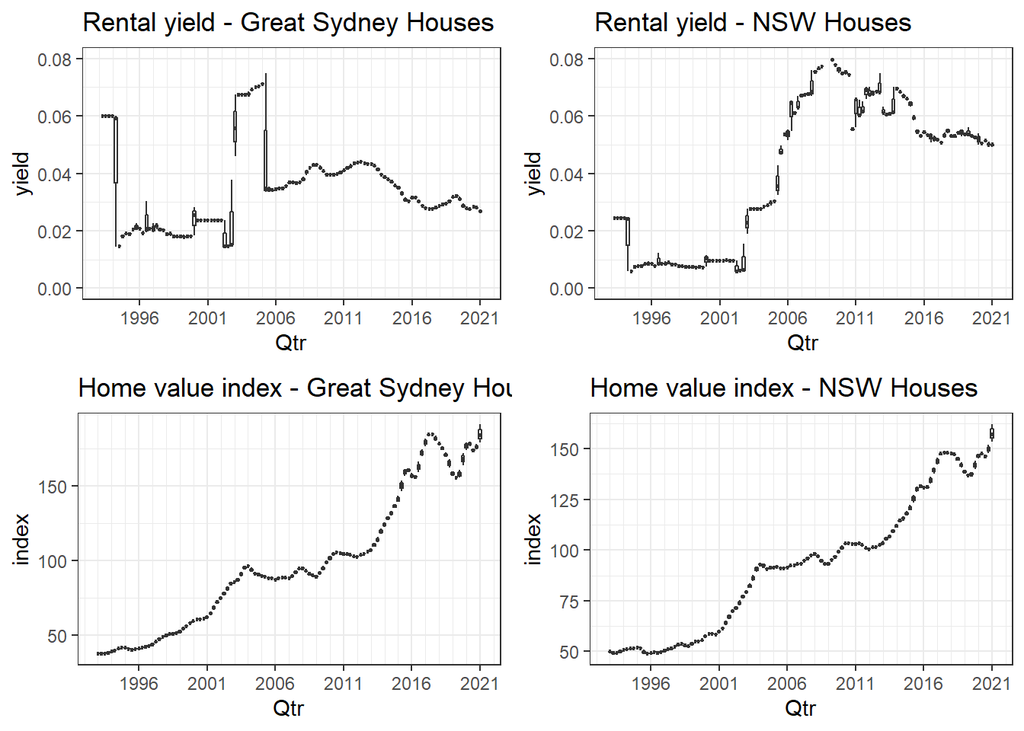

```r
start_pc_date = as.Date("1993-04-01")
start_index_date = as.Date("1993-1-01") # indexes are converted to percentages, one period short
end_date = as.Date("2021-03-31")

################################################
# ZERO-COUPON INTEREST RATES – ANALYTICAL SERIES
# import - 3 months
zcp_old = read_excel("ZCP_till2008.xls")[-c(1:10), c(1,3)]
zcp_new = read_excel("ZCP_from2008.xls")[-c(1:10), c(1,3)]
names(zcp_old) = c("Date", "ZCP3month")
names(zcp_new) = c("Date", "ZCP3month")
zcp3m = rbind(zcp_old, zcp_new)

# import - 10 years
zcp_old = read_excel("ZCP_till2008.xls")[-c(1:10), c(1,42)]
zcp_new = read_excel("ZCP_from2008.xls")[-c(1:10), c(1,42)]
names(zcp_old) = c("Date", "ZCP10year")
names(zcp_new) = c("Date", "ZCP10year")
zcp10y = rbind(zcp_old, zcp_new)
rm(zcp_new, zcp_old)

# cleaning
zcp3m = zcp3m %>% mutate_if(is.character, as.numeric)
zcp10y = zcp10y %>% mutate_if(is.character, as.numeric)
zcp3m$Date = as.Date(zcp3m$Date, origin = "1899-12-30")
zcp10y$Date = as.Date(zcp10y$Date, origin = "1899-12-30")

# convert 10 year CZP to spread
zcp10y$ZCP10y_spread = zcp10y$ZCP10year - zcp3m$ZCP3month

# match the time window
zcp3m = zcp3m %>% filter(Date <= end_date & Date >= start_pc_date)
zcp10y = zcp10y %>% filter(Date <= end_date & Date >= start_pc_date)

# match the frequency
zcp3m = zcp3m %>% mutate(Qtr = as.yearqtr(Date)) %>% group_by(Qtr) %>% summarise(ZCP3month_qtr_rate = mean(ZCP3month))
zcp10y = zcp10y %>% mutate(Qtr = as.yearqtr(Date)) %>% group_by(Qtr) %>% summarise(ZCP10y_rate_qtr_rate = mean(ZCP10year), ZCP10y_spread_qtr_rate = mean(ZCP10y_spread))

all_data_original$Date = zcp10y$Qtr
all_data_original$zcp3m = zcp3m$ZCP3month_qtr_rate
all_data_original$zcp10y = zcp10y$ZCP10y_rate_qtr_rate

# match the unit

# declare as a ts object
zcp3m = ts(zcp3m$ZCP3month_qtr_rate)
zcp10y_spread = ts(zcp10y$ZCP10y_spread_qtr_rate)

###############
# Mortgage rate
lending = read_excel("Mortgage-RBA.xls", sheet = "Data")[-c(1:10), c(1,4)]
names(lending) = c("Date", "mortgage_rate")
lending = lending %>% mutate_if(is.character, as.numeric)
lending$Date = as.Date(lending$Date, origin = "1899-12-30")

# match the time window
lending = lending %>% filter(Date <= end_date & Date >= start_pc_date)

# match the frequency
lending = lending %>% mutate(Qtr = as.yearqtr(Date)) %>% group_by(Qtr) %>% summarise(mortgage_rate_qtr = mean(mortgage_rate))

# declare as a ts object
lending = ts(lending$mortgage_rate_qtr)

######################################
# House price dynamics & rental yields
# import & cleaning
properties = read.csv("Market_Trends_Data.csv")
properties = clean_names(properties)
properties = properties %>% mutate_if(is.character, as.factor)
properties$value_at_date = as.Date(properties$value_at_date, format =  "%d/%m/%Y")

# comparing Sydney vs NSW
########
# sydney
home_value_houses_syd = properties %>%
    filter(str_detect(sa4_name16, "Sydney"), property_type == "Houses") %>%
    group_by(value_at_date) %>%
    summarise(index = mean(hedonic_home_value_index, na.rm = T))
rental_houses_syd = properties %>%
    filter(str_detect(sa4_name16, "Sydney"), property_type == "Houses") %>%
    group_by(value_at_date) %>%
    summarise(yield = mean(hedonic_rental_yields, na.rm = T))

# match the time window
home_value_houses_syd = home_value_houses_syd %>%
    filter(value_at_date <= end_date & value_at_date >= start_index_date) %>%
    mutate(Qtr = as.Date(as.yearqtr(value_at_date)))
rental_houses_syd = rental_houses_syd %>%
    filter(value_at_date <= end_date & value_at_date >= start_pc_date) %>%
    mutate(Qtr = as.Date(as.yearqtr(value_at_date)))

#####
# NSW
home_value_houses_nsw = properties %>%
    filter(state == "NSW", property_type == "Houses") %>%
    group_by(value_at_date) %>%
    summarise(index = mean(hedonic_home_value_index, na.rm = T))
rental_houses_nsw = properties %>%
    filter(state == "NSW", property_type == "Houses") %>%
    group_by(value_at_date) %>%
    summarise(yield = mean(hedonic_rental_yields, na.rm = T))
home_value_houses_nsw = home_value_houses_nsw %>%
    filter(value_at_date <= end_date & value_at_date >= start_index_date) %>%
    mutate(Qtr = as.Date(as.yearqtr(value_at_date)))
rental_houses_nsw = rental_houses_nsw %>%
    filter(value_at_date <= end_date & value_at_date >= start_pc_date) %>%
    mutate(Qtr = as.Date(as.yearqtr(value_at_date)))

plot_rent_syd = ggplot(rental_houses_syd) +
    geom_boxplot(aes(Qtr, yield, group = Qtr)) +
    theme_bw() +
    labs(title = "Rental yield - Great Sydney Houses", ylab = "(%)") +
    scale_x_date(breaks = "5 years", minor_breaks = "1 years", date_labels = "%Y") +
    scale_y_continuous(limits = c(0,0.08))
plot_rent_nsw = ggplot(rental_houses_nsw) +
    geom_boxplot(aes(Qtr, yield, group = Qtr)) +
    theme_bw() +
    labs(title = "Rental yield - NSW Houses", ylab = "(%)") +
    scale_x_date(breaks = "5 years", minor_breaks = "1 years", date_labels = "%Y") +
    scale_y_continuous(limits = c(0,0.08))
plot_house_syd = ggplot(home_value_houses_syd) +
    geom_boxplot(aes(Qtr, index, group = Qtr)) +
    theme_bw() +
    labs(title = "Home value index - Great Sydney Houses", ylab = "(%)") +
    scale_x_date(breaks = "5 years", minor_breaks = "1 years", date_labels = "%Y")
plot_house_nsw = ggplot(home_value_houses_nsw) +
    geom_boxplot(aes(Qtr, index, group = Qtr)) +
    theme_bw() +
    labs(title = "Home value index - NSW Houses", ylab = "(%)") +
    scale_x_date(breaks = "5 years", minor_breaks = "1 years", date_labels = "%Y")
grid.arrange(plot_rent_syd, plot_rent_nsw, plot_house_syd, plot_house_nsw, nrow = 2)
```

```r
# match the frequency
home_value_houses_nsw = home_value_houses_nsw %>%
    group_by(Qtr) %>%
    summarise(home_val_qtr = mean(index))
rental_houses_nsw = rental_houses_nsw %>%
    group_by(Qtr) %>%
    summarise(rental_yields_qtr_rate = mean(yield))

all_data_original$home_index = home_value_houses_nsw$home_val_qtr[-1]
all_data_original$rental_yield = rental_houses_nsw$rental_yields_qtr_rate

# match the unit
home_value_houses_nsw = home_value_houses_nsw %>% mutate(home_value_qtr_rate = log(home_val_qtr) - log(dplyr::lag(home_val_qtr, n = 1)))
home_value_houses_nsw = home_value_houses_nsw[-1,]

# declares variables as time_series objects
home_value_houses_nsw = ts(home_value_houses_nsw$home_value_qtr_rate)
rental_houses_nsw = ts(rental_houses_nsw$rental_yields_qtr_rate)

####################################################################
# Gross domestic product: Chain volume measures; seasonally adjusted
# import
gdp = read_excel("GDP-ABS.xls", sheet = "Data1")[-c(1:9), c(1,54)]
names(gdp) = c("Date", "GDP")
gdp = gdp %>% mutate_if(is.character, as.numeric)
gdp$Date = as.Date(gdp$Date, origin = "1899-12-30")

# match the time window
gdp = gdp %>% filter(Date <= end_date & Date >= start_index_date)

# match the frequency
gdp = gdp %>% mutate(Qtr = as.yearqtr(Date)) %>% dplyr::select(-Date)
all_data_original$GDP = gdp$GDP[-1]

# match the unit
gdp = gdp %>% mutate(gdp_rates = log(GDP) - log(dplyr::lag(GDP, n = 1)))
gdp = gdp[-1,]

# declare as a ts object
gdp = ts(gdp$gdp_rates)

#####################################
# CPI: Australia; seasonally adjusted
# import
cpi = read_excel("CPI-ABS.xls", sheet = "Data1")[-c(1:9), c(1,10)]
names(cpi) = c("Date", "CPI")
cpi = cpi %>% mutate_if(is.character, as.numeric)
cpi$Date = as.Date(cpi$Date, origin = "1899-12-30")

# match the time window
cpi = cpi %>% filter(Date <= end_date & Date >= start_index_date)

# match the frequency
cpi = cpi %>% mutate(Qtr = as.yearqtr(Date)) %>% dplyr::select(-Date)
all_data_original$CPI = cpi$CPI[-1]

# match the unit
cpi = cpi %>% mutate(cpi_rate = log(CPI) - log(dplyr::lag(CPI, n = 1)))
cpi = cpi[-1,]

# declare as a ts object
cpi = ts(cpi$cpi_rate)

##################################################################
# Non-financial corporate BBB bonds – yield – 10 year target tenor
# import
# corpBBB_10y_spread = read_excel("corporate_bonds-RBA.xls", sheet = "Data")[-c(1:10), c(1,36)]
# names(corpBBB_10y_spread) = c("Date", "yield")
# corpBBB_10y_spread = corpBBB_10y_spread %>% mutate_if(is.character, as.numeric)
# corpBBB_10y_spread$Date = as.Date(corpBBB_10y_spread$Date, origin = "1899-12-30")
#
# # match the time window
# corpBBB_10y_spread = corpBBB_10y_spread %>% filter(Date <= end_date & Date >= start_pc_date)
#
# # match the frequency
# corpBBB_10y_spread = corpBBB_10y_spread %>% mutate(Qtr = as.yearqtr(Date)) %>% group_by(Qtr) %>% summarise(yield_qtr = mean(yield))
#
# # match the unit
# corpBBB_10y_spread$spread_qtr = corpBBB_10y_spread$yield_qtr - zcp3m
#
# # declare as a ts object
# corpBBB_10y_spread = ts(corpBBB_10y_spread$spread_qtr)

#################################
# S&P/ASX200: daily closing price
# import
asx200_new = read_excel("ASX200_from2001.xlsx")[, 1:2]
asx200_new = clean_names(asx200_new)

asx200_oldest = read_excel("ASX200_till2001Q2.xlsx")[,c(1,6)]
names(asx200_oldest) = c("exchange_date", "close")
asx200_oldest = asx200_oldest %>% mutate_if(is.character, as.numeric)
asx200_oldest$exchange_date = as.Date(asx200_oldest$exchange_date, origin = "1899-12-30")
asx200_oldest = asx200_oldest[order(asx200_oldest$exchange_date),]

asx200_old = read_excel("ASX200_till2001Nov19.xlsx")[,c(1,6)]
names(asx200_old) = c("exchange_date", "close")
asx200_old = asx200_old %>% mutate_if(is.character, as.numeric)
asx200_old$exchange_date = as.Date(asx200_old$exchange_date, origin = "1899-12-30")
asx200_old = asx200_old[order(asx200_old$exchange_date),]

asx200 = rbind(asx200_oldest, asx200_old, asx200_new)

# match the time window
asx200 = asx200 %>% filter(exchange_date <= end_date & exchange_date >= start_index_date)

# match the frequency
asx200 = asx200 %>% mutate(Qtr = as.yearqtr(exchange_date)) %>% group_by(Qtr) %>% summarise(close_qtr_price = mean(close, na.rm = T))
all_data_original$ASX200 = asx200$close_qtr_price[-1]

# match the unit
asx200 = asx200 %>% mutate(close_qtr_rate = log(close_qtr_price) - log(dplyr::lag(close_qtr_price, n = 1)))
asx200 = asx200[-1,]

# declare as a ts object
asx200 = ts(asx200$close_qtr_rate)

############################################
# unemployment rate NSW; seasonally adjusted
# import
unemploy_nsw = read_excel("Unemployment NSW-ABS.xls", sheet = "Data1")[-c(1:9), c(1, 48)]
names(unemploy_nsw) = c("Date", "Unemployment_rate")
unemploy_nsw = unemploy_nsw %>% mutate_if(is.character, as.numeric)
unemploy_nsw$Date = as.Date(unemploy_nsw$Date, origin = "1899-12-30")

# match the time window
unemploy_nsw = unemploy_nsw %>% filter(Date <= end_date & Date >= start_pc_date)

# match the frequency
unemploy_nsw = unemploy_nsw %>% mutate(Qtr = as.yearqtr(Date)) %>% group_by(Qtr) %>% summarise(unemploy_qtr_rate = mean(Unemployment_rate))
all_data_original$unemploy = unemploy_nsw$unemploy_qtr_rate

# match the unit

# declare as a ts object
unemploy_nsw = ts(unemploy_nsw$unemploy_qtr_rate)

###############################################
# forex: Australian Dollar Trade-weighted Index
# import
forex1 = read_excel("Forex_till2010.xls")[-c(1:20), c(1,15)]
forex2 = read_excel("Forex_from2010.xls")[-c(1:10), c(1,3)]
names(forex1) = c("Date", "AUD_index")
names(forex2) = c("Date", "AUD_index")
forex = rbind(forex1, forex2)
forex = forex %>% mutate_if(is.character, as.numeric)
forex$Date = as.Date(forex$Date, origin = "1899-12-30")
rm(forex1, forex2)

# match the time window
forex = forex %>% filter(Date <= end_date & Date >= start_index_date)

# match the frequency
forex = forex %>% mutate(Qtr = as.yearqtr(Date)) %>% group_by(Qtr) %>% summarise(AUD_qtr_index = mean(AUD_index))
all_data_original$forex = forex$AUD_qtr_index[-1]

# match the unit
forex = forex %>% mutate(AUD_qtr_rate = log(AUD_qtr_index) - log(dplyr::lag(AUD_qtr_index, n = 1)))
forex = forex[-1,]

# declare as a ts object
forex = ts(forex$AUD_qtr_rate)
```

## 2.2 Analyse the time series characteristics

### 2.2.1 Raw data plots

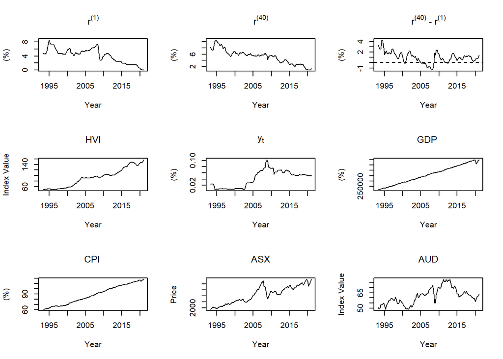

```r
##################
# individual plots
par(mfrow = c(3,3))
# 3-month zero-coupon yields
plot(all_data_original$Date, all_data_original$zcp3m, "l", ylab = "(%)", xlab = "Year", main = TeX("r^{(1)}"))
# 10-year zero-coupon yield
plot(all_data_original$Date, all_data_original$zcp10y, "l", ylab = "(%)", xlab = "Year", main = TeX("r^{(40)}"))
# 10-year zero-coupon spread
plot(all_data_original$Date, zcp10y_spread, "l", ylab = "(%)", xlab = "Year", main = TeX("r^{(40)} - r^{(1)}"))
abline(h = 0, lty = 2)
# Hedonic home value index \n Sydney houses
plot(all_data_original$Date, all_data_original$home_index, "l", ylab = "Index Value", xlab = "Year", main = TeX("HVI"))
# Hedonic rental yields \n Sydney houses
plot(all_data_original$Date, all_data_original$rental_yield, "l", ylab = "(%)", xlab = "Year", main = TeX("y_t"))
abline(h = 0, lty = 2)
# GDP
plot(all_data_original$Date, all_data_original$GDP, "l", ylab = "(%)", xlab = "Year", main = TeX("GDP "))
# CPI
plot(all_data_original$Date, all_data_original$CPI, "l", ylab = "(%)", xlab = "Year", main = TeX("CPI "))
# S&P/ASX200 closing price
plot(all_data_original$Date, all_data_original$ASX200, "l", ylab = "Price", xlab = "Year", main = TeX("ASX"))
# NSW unemployment rates
# plot(all_data_original$Date, all_data_original$unemploy, "l", ylab = "(%)", xlab = "Year", main = "UE")
# AUD trade-weighted index
plot(all_data_original$Date, all_data_original$forex, "l", ylab = "Index Value", xlab = "Year", main = TeX("AUD"))
```

### 2.2.2 Transformed data plots

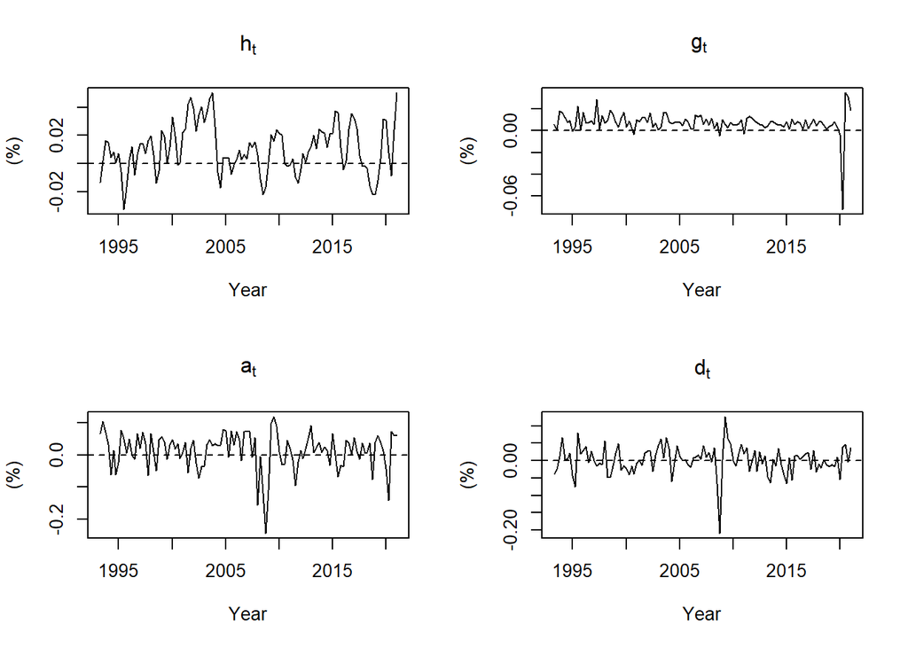

```r
##################
# individual plots
all_data = cbind(zcp3m, zcp10y_spread, home_value_houses_nsw, rental_houses_nsw, gdp, asx200, forex)
par(mfrow = c(2,2))
# plot(zcp10y$Qtr, zcp10y_spread, "l", ylab = "spread", xlab = "", main = "10-year zero-coupon spread")
plot(zcp10y$Qtr, home_value_houses_nsw, "l", ylab = "(%)", xlab = "Year", main = TeX("h_t"))
abline(h = 0, lty = 2)
# plot(zcp10y$Qtr, rental_houses_nsw, "l", ylab = "yield", xlab = "", main = "Hedonic rental yields \n Sydney houses")
plot(zcp10y$Qtr, gdp, "l", ylab = "(%)", xlab = "Year", main = TeX("g_t "))
abline(h = 0, lty = 2)
# plot(zcp10y$Qtr, corpBBB_10y_spread, "l")
plot(zcp10y$Qtr, asx200, "l", ylab = "(%)", xlab = "Year", main = TeX("a_t"))
abline(h = 0, lty = 2)
# plot(zcp10y$Qtr, unemploy_nsw, "l", ylab = "rate", xlab = "", main = "NSW unemployment rates")
plot(zcp10y$Qtr, forex, "l", ylab = "(%)", xlab = "Year", main = TeX("d_t"))
abline(h = 0, lty = 2)
```

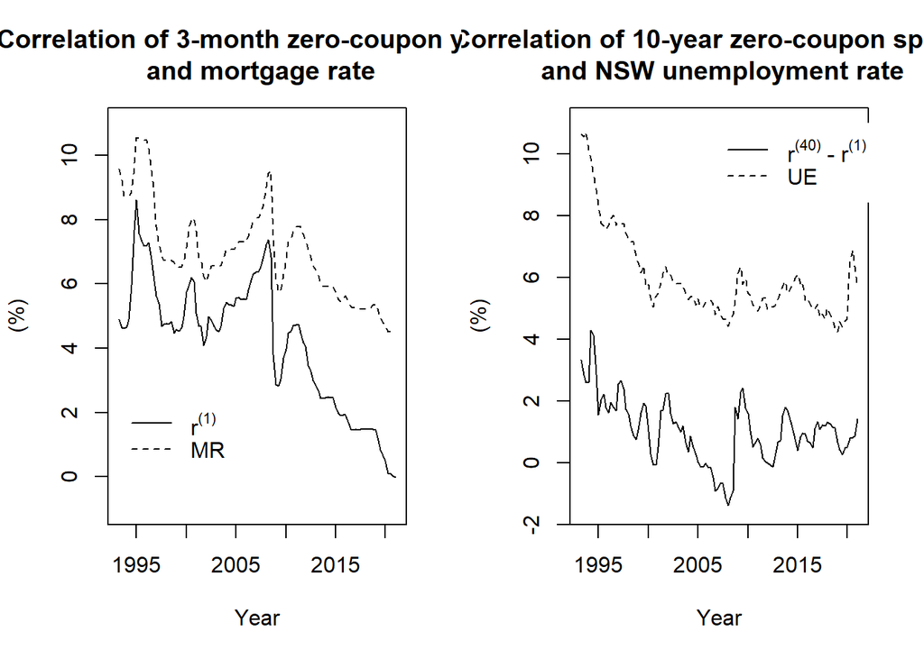

```r
##########
# combined
par(mfrow = c(1,2))
# zcp3m vs mortgage
plot(all_data_original$Date, all_data_original$zcp3m, "l", ylab = "(%)", ylim = c(-1,11), xlab = "Year", main = "Correlation of 3-month zero-coupon yield \n and mortgage rate")
lines(all_data_original$Date, lending, "l", lty = 2)
legend(1992.5, 2.5, legend = c(TeX("r^{(1)}"), "MR"), lty = 1:2, box.lty = 0)

# GDP vs CPI
# plot(all_data_original$Date, gdp, "l", ylab = "(%)", ylim = c(-0.08,0.04), xlab = "Year", main = "")
# lines(all_data_original$Date, cpi, "l", lty = 2)
# legend(1992.5, -0.065, legend = c(TeX("g_t"), TeX("c_t")), lty = 1:2, box.lty = 0)

# unemployment vs zcp10y
plot(all_data_original$Date, zcp10y_spread, "l", ylab = "(%)", ylim = c(-1.5,11), xlab = "Year", main = "Correlation of 10-year zero-coupon spread \n and NSW unemployment rate")
lines(all_data_original$Date, unemploy_nsw, "l", lty = 2)
legend(2006, 11, legend = c(TeX("r^{(40)} - r^{(1)}"), TeX("UE")), lty = 1:2, box.lty = 0)
```

### 2.2.3 Correlation

- `Mortgage rate` vs `3-month zero-coupon yield` ($\rho$ = 0.90). Mortgage rate removed.
- `10-year zero-coupon spread` vs `NSW unemployment rate` ($\rho$ = 0.75). Unemployment rate removed.
- `10-year zero-coupon spread` vs `10-year BBB-rated corporate bond spread` ($\rho$ = 0.621). Corporate bond was removed.
- `S&P/ASX200 growth` vs `AUD trade index growth` ($\rho$ = 0.42). Both kept.

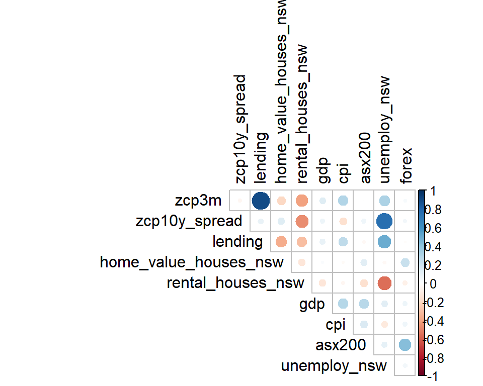

```r
all_data = cbind(zcp3m, zcp10y_spread, lending, home_value_houses_nsw, rental_houses_nsw, gdp, cpi, asx200, unemploy_nsw, forex)
######
# corr
par(mfrow = c(1,1))
corrplot(cor(all_data, method = "pearson"), tl.col = "black", diag = F, type = "upper", tl.srt = 90)
```

### 2.2.4 Principal Component Analysis

On the 1st and 2nd principal components:

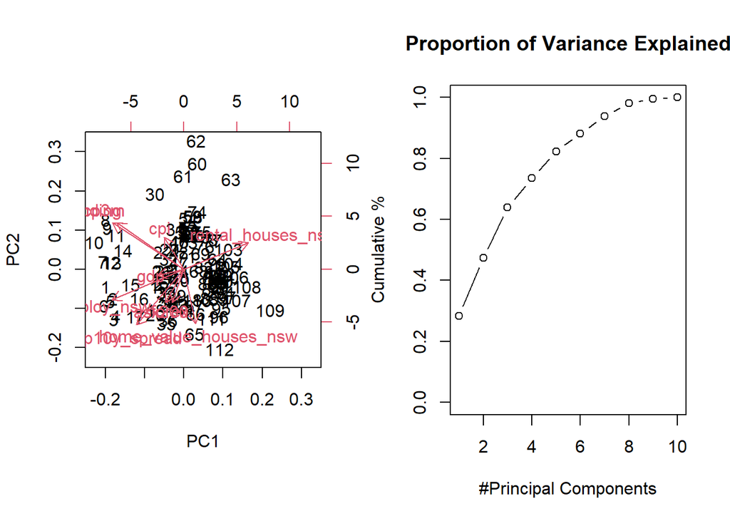

```r
set.seed(1)
all_pca = prcomp(all_data, scale = T)

par(mfrow = c(1,2))
biplot(all_pca)

# proportion of variance explained
pve = (all_pca$sdev ^ 2 / sum(all_pca$sdev ^ 2))
plot(cumsum(pve), xlab = "#Principal Components", main = "Proportion of Variance Explained", ylab = "Cumulative %", ylim = c(0,1), type = "b")
```

```r
all_data = cbind(zcp3m, zcp10y_spread, home_value_houses_nsw, rental_houses_nsw, gdp, cpi, asx200, forex)
```

# 3 Stationarity for individual variables

## 3.1 Statistical tests for stationarity

- Augmented Dickey–Fuller test ($H_0$: unit root present in the series).
- Phillips-Perron test ($H_0$: integrated of order 1).
- Significant level is chosen to be 0.05. pvalue = 0.01 means <= 0.01. No laps at this stage.
- Series to be transformed are: `3-month zero-coupon yield`, `Hedonic rental yields - Sydney houses`.

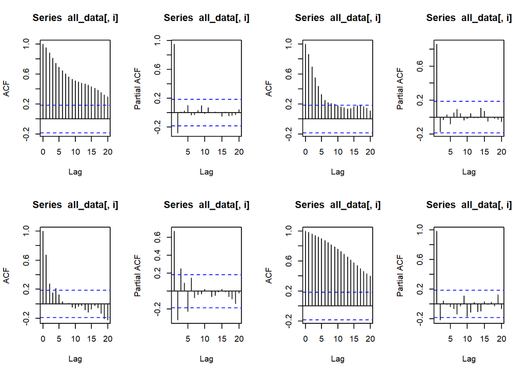

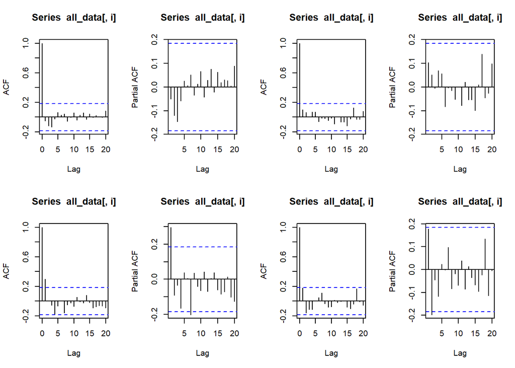

```r
###############
# ACF/PACF plots
par(mfrow = c(2,4))
for (i in 1:length(all_var_names)) {
  acf(all_data[,i])
  pacf(all_data[,i])
}
```

```r
sig_level = 0.05 # pvalue threshold


########################
# choose the correct lag
# PP tests
adf_test_lag = function (x, sig_level = 0.05) {
    output = data.frame(stats = NA, pvalue = NA)
    results = adf.test(x)$type1
    i = 1
    output$stats = results[i,2]
    output$pvalue = results[i,3]
    while (output$pvalue > sig_level & i <= 4) {
        i = i + 1
        output$stats = results[i,2]
        output$pvalue = results[i,3]
    }
    return (output)
}



##############################
# Augmented Dickey–Fuller test
adf_results = data.frame(ADF_statistics = rep(NA,length(all_var_names)), ADF_pvalues = rep(NA,length(all_var_names)), row.names = all_var_names)
for (i in 1:length(all_var_names)) {
  results = adf_test_lag(all_data[,i])
  adf_results[i,1] = results$stats
  adf_results[i,2] = results$pvalue
}
adf_results = adf_results %>% mutate(ADF_stationary = ifelse(ADF_pvalues <= sig_level, "Yes", "No evidence"))

######################
# Phillips-Perron test
pp_results = data.frame(PP_statistics = rep(NA, length(all_var_names)), PP_pvalues = rep(NA, length(all_var_names)), row.names = all_var_names)
for (i in 1:ncol(all_data)) {
  results = aTSA::pp.test(all_data[,i])
  pp_results[i,1] = results[1,2]
  pp_results[i,2] = results[1,3]
}
pp_results = pp_results %>% mutate(PP_stationary = ifelse(PP_pvalues <= sig_level, "Yes", "No evidence"))
```

```r
########################
# vars to be transformed
non_stationary_var_names = c("3-month zero-coupon yield", "Hedonic rental yields - Sydney houses")
pp_results_trans = data.frame(PP_statistics = rep(NA, length(non_stationary_var_names)), PP_pvalues = rep(NA, length(non_stationary_var_names)), row.names = non_stationary_var_names)
adf_results_trans = data.frame(ADF_statistics = rep(NA, length(non_stationary_var_names)), ADF_pvalues = rep(NA, length(non_stationary_var_names)), row.names = non_stationary_var_names)

###########################
# printing the prev results
# pvalue = 0.01 actually means pvalue < 0.01
print_pvalue = function (x) {
    # input is a vector of pvalues
    output = ifelse(x == 0.01, "< 0.01", x)
}

# print results
stationary_results_lag4 = cbind(adf_results, pp_results)
stationary_results_lag4$ADF_pvalues = print_pvalue(stationary_results_lag4$ADF_pvalues)
stationary_results_lag4$PP_pvalues = print_pvalue(stationary_results_lag4$PP_pvalues)
kbl(stationary_results_lag4) %>% kable_styling(latex_options = c("striped", "scale_down"))
```

|  | ADF_statistics | ADF_pvalues | ADF_stationary | PP_statistics | PP_pvalues | PP_stationary |
| --- | --- | --- | --- | --- | --- | --- |
| zcp3m | -1.058103 | 0.299014468056799 | No evidence | -1.463438 | 0.448475418367852 | No evidence |
| zcp10y | -2.448497 | 0.0162770789948442 | Yes | -9.231348 | 0.0356542723330542 | Yes |
| home_index | -3.285113 | < 0.01 | Yes | -21.280940 | < 0.01 | Yes |
| rental_yield | -0.092049 | 0.616618533615181 | No evidence | -0.186465 | 0.647615229719231 | No evidence |
| GDP | -7.346686 | < 0.01 | Yes | -83.612857 | < 0.01 | Yes |
| CPI | -5.415027 | < 0.01 | Yes | -47.444847 | < 0.01 | Yes |
| ASX200 | -7.449139 | < 0.01 | Yes | -68.835495 | < 0.01 | Yes |
| forex | -8.732558 | < 0.01 | Yes | -77.770950 | < 0.01 | Yes |

## 3.2 Transform if non-stationary

```r
###########################
# 3-month zero-coupon yield
# differencing
zcp3m_stationary = zcp3m - dplyr::lag(as.vector(zcp3m), n = 1)
zcp3m_stationary = ts(zcp3m_stationary[-1])

# store new stationarity test results
pp_results_trans[1,1] = tseries::pp.test(zcp3m_stationary)$statistic
pp_results_trans[1,2] = tseries::pp.test(zcp3m_stationary)$p.value
results = adf.test(zcp3m_stationary)$type1
adf_results_trans[1,1] = results[1,2] # stats
adf_results_trans[1,2] = results[1,3] # pvalue

############################
# 10-year zero-coupon spread
# differencing
# zcp10y_spread_stationary = zcp10y_spread - dplyr::lag(as.vector(zcp10y_spread), n = 1)
# zcp10y_spread_stationary = ts(zcp10y_spread_stationary[-1])
#
# # store new stationarity test results
# pp_results_trans[2,1] = tseries::pp.test(zcp10y_spread_stationary)$statistic
# pp_results_trans[2,2] = tseries::pp.test(zcp10y_spread_stationary)$p.value
# results = adf.test(zcp10y_spread_stationary)$type1
# adf_results_trans[2,1] = results[1,2] # stats
# adf_results_trans[2,2] = results[1,3] # pvalue

#######################################
# Hedonic rental yields - NSW houses
# differencing
rental_houses_nsw_stationary = rental_houses_nsw - dplyr::lag(as.vector(rental_houses_nsw), n = 1)
rental_houses_nsw_stationary = ts(rental_houses_nsw_stationary[-1])

# store new stationarity test results
results = tseries::pp.test(rental_houses_nsw_stationary)
pp_results_trans[2,1] = results$statistic
pp_results_trans[2,2] = results$p.value
results = adf.test(rental_houses_nsw_stationary)$type1
adf_results_trans[2,1] = results[1,2] # stats
adf_results_trans[2,2] = results[1,3] # pvalue


#########################
# Unemployment rate - NSW
# # differencing
# unemploy_nsw_stationary = unemploy_nsw - dplyr::lag(as.vector(unemploy_nsw), n = 1)
# unemploy_nsw_stationary = ts(unemploy_nsw_stationary[-1])
#
# # store new stationarity test results
# results = tseries::pp.test(unemploy_nsw_stationary)
# pp_results_trans[4,1] = results$statistic
# pp_results_trans[4,2] = results$p.value
# results = adf.test(unemploy_nsw_stationary)$type1
# adf_results_trans[4,1] = results[1,2] # stats
# adf_results_trans[4,2] = results[1,3] # pvalue

####################
# match time windows
zcp10y_spread = ts(zcp10y_spread[-1])
home_value_houses_nsw = ts(home_value_houses_nsw[-1])
gdp = ts(gdp[-1])
cpi = ts(cpi[-1])
asx200 = ts(asx200[-1])
forex = ts(forex[-1])
```

```r
pp_results_trans = pp_results_trans %>% mutate(PP_stationary = ifelse(PP_pvalues <= 0.05, "Yes", "No evidence"))
adf_results_trans = adf_results_trans %>% mutate(ADF_stationary = ifelse(ADF_pvalues <= 0.05, "Yes", "No evidence"))

stationary_results_lag1 = cbind(adf_results_trans, pp_results_trans)
stationary_results_lag1$ADF_pvalues = print_pvalue(stationary_results_lag1$ADF_pvalues)
stationary_results_lag1$PP_pvalues = print_pvalue(stationary_results_lag1$PP_pvalues)
kbl(stationary_results_lag1) %>% kable_styling(latex_options = c("striped", "scale_down"))
```

|  | ADF_statistics | ADF_pvalues | ADF_stationary | PP_statistics | PP_pvalues | PP_stationary |
| --- | --- | --- | --- | --- | --- | --- |
| 3-month zero-coupon yield | -6.42009 | < 0.01 | Yes | -55.1799 | < 0.01 | Yes |
| Hedonic rental yields - Sydney houses | -8.16077 | < 0.01 | Yes | -79.6425 | < 0.01 | Yes |

# 4 Full VAR

## 4.1 Find the optimal order p

Notes on R built-in functions:

- Formulas for the statistics ([link](http://www.phdeconomics.sssup.it/documents/Lesson18.pdf)). Ouput `HQ` is HQC, `SIC` is BIC, `FPE` is final prediction error.
- `VARSelect` for every lag up to maximum are based on the same sample size, which is not suitable. We compute the statistics mannually.
- `AIC()`, `BIC()` do not use the right residual covariance.

Three types of VAR deterministic regressors:

- `none`: optimal lag is 1.

  $$\begin{align*}
  \mathbf{y}_{t} = \boldsymbol{\beta}_{1}\mathbf{y}_{t-1}+ \boldsymbol{\beta}_{2}\mathbf{y}_{t-2}+\cdots++ \boldsymbol{\beta}_{p}\mathbf{y}_{t-p} + \boldsymbol{\epsilon}. \end{align*}$$
- `const`: optimal lag is 1.

$$\begin{align*}
\mathbf{y}_{t} = \boldsymbol{\alpha} + \boldsymbol{\beta}_{1}\mathbf{y}_{t-1}+ \boldsymbol{\beta}_{2}\mathbf{y}_{t-2}+\cdots++ \boldsymbol{\beta}_{p}\mathbf{y}_{t-p} + \boldsymbol{\epsilon}. \end{align*}$$

- `trend`: optimal lag is 1.

$$\begin{align*}
\mathbf{y}_{t} = \boldsymbol{\alpha} + \boldsymbol{\gamma }t + \boldsymbol{\beta}_{1}\mathbf{y}_{t-1}+ \boldsymbol{\beta}_{2}\mathbf{y}_{t-2}+\cdots++ \boldsymbol{\beta}_{p}\mathbf{y}_{t-p} + \boldsymbol{\epsilon}. \end{align*}$$

- `both`: `const` and `trend`. optimal lag is 1.

```r
all_data_stationary = cbind(zcp3m_stationary, zcp10y_spread, home_value_houses_nsw, rental_houses_nsw_stationary, gdp, cpi, asx200, forex)
max_lag = 10

choose_order = function (type, max_lag) {
  # returns a dataframe containing all statistics up to max_lag

  # compute the statistics
  output = data.frame(lag = 1:max_lag, AIC = rep(NA, max_lag), AIC_select = rep(NA, max_lag), SIC = rep(NA, max_lag), SIC_select = rep(NA, max_lag), HQC = rep(NA, max_lag), HQC_select = rep(NA, max_lag))
  for (lag in 1:max_lag) {
    results = VAR(all_data_stationary, type = type, p = lag)
    summ_results = summary(results)
    output[lag,2] = log(det(summ_results$covres)) + 2 * lag * results$K ^ 2 / results$obs # AIC
    output[lag,4] = log(det(summ_results$covres)) + results$K ^ 2 * lag * log(results$obs) / results$obs # SIC
    output[lag,6] = log(det(summ_results$covres)) + results$K ^ 2 * lag * 2 * log(log(results$obs)) / results$obs # HQC
  }

  # find optimal order
  output$AIC_select = ifelse(output$AIC == min(output$AIC), "*", NA)
  output$SIC_select = ifelse(output$SIC == min(output$SIC), "*", NA)
  output$HQC_select = ifelse(output$HQC == min(output$HQC), "*", NA)

  # prints
  return (output)
}

######
"none"
```

```
## [1] "none"
```

```r
choose_order_none = choose_order("none", max_lag)
# kbl(choose_order_none) %>% kable_styling(latex_options = c("striped", "scale_down"))
optimal_none_order = 1

#######
"const"
```

```
## [1] "const"
```

```r
choose_order_const = choose_order("const", max_lag)
kbl(choose_order_const) %>% kable_styling(latex_options = c("striped", "scale_down"))
```

lag

AIC

AIC_select

SIC

SIC_select

HQC

HQC_select

1

-55.5357

-53.9645

-54.8984

2

-54.4097

NA

-51.2492

NA

-53.1280

NA

3

-53.1920

NA

-48.4237

NA

-51.2586

NA

4

-52.2578

NA

-45.8630

NA

-49.6654

NA

5

-51.3527

NA

-43.3122

NA

-48.0939

NA

6

-50.2916

NA

-40.5857

NA

-46.3585

NA

7

-49.3527

NA

-37.9615

NA

-44.7378

NA

8

-49.0406

NA

-35.9436

NA

-43.7359

NA

9

-48.6023

NA

-33.7789

NA

-42.5998

NA

10

-49.4398

NA

-32.8687

NA

-42.7314

NA

```r
optimal_const_order = 1

#######
"trend"
```

```
## [1] "trend"
```

```r
choose_order_trend = choose_order("trend", max_lag)
# kbl(choose_order_trend) %>% kable_styling(latex_options = c("striped", "scale_down"))
optimal_trend_order = 1

######
"both"
```

```
## [1] "both"
```

```r
choose_order_both = choose_order("both", max_lag)
# kbl(choose_order_both) %>% kable_styling(latex_options = c("striped", "scale_down"))
optimal_both_order = 1

#####################
# compare the 4 types
# collect the stats
choose_all = data.frame(type = c("none", "const", "trend", "both"),
                        best_lag = c(optimal_none_order, optimal_const_order, optimal_trend_order, optimal_both_order),
                        AIC = rep(NA, 4), AIC_select = rep(NA,4),
                        SIC = rep(NA, 4), SIC_select = rep(NA,4),
                        HQC = rep(NA, 4), HQC_select = rep(NA,4))
choose_all[1,c(3,5,7)] = c(choose_order_none$AIC[optimal_none_order], choose_order_none$SIC[optimal_none_order], choose_order_none$HQC[optimal_none_order])
choose_all[2, c(3,5,7)] = c(choose_order_const$AIC[optimal_const_order], choose_order_const$SIC[optimal_const_order], choose_order_const$HQC[optimal_const_order])
choose_all[3,c(3,5,7)] = c(choose_order_trend$AIC[optimal_trend_order], choose_order_trend$SIC[optimal_trend_order], choose_order_trend$HQC[optimal_trend_order])
choose_all[4,c(3,5,7)] = c(choose_order_both$AIC[optimal_both_order], choose_order_both$SIC[optimal_both_order], choose_order_both$HQC[optimal_both_order])

# choose the best type: constant
choose_all$AIC_select = ifelse(choose_all$AIC == min(choose_all$AIC), "*", NA)
choose_all$SIC_select = ifelse(choose_all$SIC == min(choose_all$SIC), "*", NA)
choose_all$HQC_select = ifelse(choose_all$HQC == min(choose_all$HQC), "*", NA)
kbl(choose_all) %>% kable_styling(latex_options = c("striped", "scale_down"))
```

type

best_lag

AIC

AIC_select

SIC

SIC_select

HQC

HQC_select

none

1

-55.2250

NA

-53.6538

NA

-54.5877

NA

const

1

-55.5357

NA

-53.9645

NA

-54.8984

NA

trend

1

-55.2691

NA

-53.6979

NA

-54.6318

NA

both

1

-55.5665

-53.9953

-54.9292

```r
optimal_order = optimal_const_order
```

## 4.2 Train the model

```r
num_test = round(length(zcp3m) * 0.2)
train_index = 1:(nrow(all_data_original) - num_test - 1)
end_train_index = max(train_index)

test = all_data_stationary[-train_index, ]
train = all_data_stationary[train_index,]
```

Build VAR(1) on the training set.

```r
get_coef = function (x) {
    # x is a VAR object
    coef_var = coef(x)

    results = data.frame(Coeff = rep(NA, length(all_var_names)),
                         SE = rep(NA, length(all_var_names)),
                         Coeff1 = rep(NA, length(all_var_names)),
                         SE1 = rep(NA, length(all_var_names)),
                         Coeff2 = rep(NA, length(all_var_names)),
                         SE2 = rep(NA, length(all_var_names)),
                         Coeff3 = rep(NA, length(all_var_names)),
                         SE3 = rep(NA, length(all_var_names)),
                         Coeff4 = rep(NA, length(all_var_names)),
                         SE4 = rep(NA, length(all_var_names)),
                         Coeff5 = rep(NA, length(all_var_names)),
                         SE5 = rep(NA, length(all_var_names)),
                         Coeff6 = rep(NA, length(all_var_names)),
                         SE6 = rep(NA, length(all_var_names)),
                         Coeff7 = rep(NA, length(all_var_names)),
                         SE7 = rep(NA, length(all_var_names)),
                         Coeff8 = rep(NA, length(all_var_names)),
                         SE8 = rep(NA, length(all_var_names)),
                         row.names = all_var_names)

    # intercept
    results[,1] = c(coef_var$zcp3m_stationary[length(all_var_names)+1,1],
                    coef_var$zcp10y_spread[length(all_var_names)+1,1],
                    coef_var$home_value_houses_nsw[length(all_var_names)+1,1],
                    coef_var$rental_houses_nsw_stationary[length(all_var_names)+1,1],
                    coef_var$gdp[length(all_var_names)+1,1],
                    coef_var$cpi[length(all_var_names)+1,1],
                    coef_var$asx200[length(all_var_names)+1,1],
                    coef_var$forex[length(all_var_names)+1,1])
    results[,2] = c(coef_var$zcp3m_stationary[length(all_var_names)+1,2],
                    coef_var$zcp10y_spread[length(all_var_names)+1,2],
                    coef_var$home_value_houses_nsw[length(all_var_names)+1,2],
                    coef_var$rental_houses_nsw_stationary[length(all_var_names)+1,2],
                    coef_var$gdp[length(all_var_names)+1,2],
                    coef_var$cpi[length(all_var_names)+1,2],
                    coef_var$asx200[length(all_var_names)+1,2],
                    coef_var$forex[length(all_var_names)+1,2])
    coef_index = seq(from = 3, to = 18, by = 2)
    se_index = seq(from = 4, to = 18, by = 2)
    # zcp3m row
    results[1,coef_index] = coef_var$zcp3m_stationary[1:length(all_var_names),1]
    results[1,se_index] = coef_var$zcp3m_stationary[1:length(all_var_names),2]
    # zcp10y row
    results[2,coef_index] = coef_var$zcp10y_spread[1:length(all_var_names),1]
    results[2,se_index] = coef_var$zcp10y_spread[1:length(all_var_names),2]
    # home value
    results[3,coef_index] = coef_var$home_value_houses_nsw[1:length(all_var_names),1]
    results[3,se_index] = coef_var$home_value_houses_nsw[1:length(all_var_names),2]
    # rental
    results[4,coef_index] = coef_var$rental_houses_nsw_stationary[1:length(all_var_names),1]
    results[4,se_index] = coef_var$rental_houses_nsw_stationary[1:length(all_var_names),2]
    # gdp
    results[5,coef_index] = coef_var$gdp[1:length(all_var_names),1]
    results[5,se_index] = coef_var$gdp[1:length(all_var_names),2]
    # cpi
    results[6,coef_index] = coef_var$cpi[1:length(all_var_names),1]
    results[6,se_index] = coef_var$cpi[1:length(all_var_names),2]
    # asx
    results[7,coef_index] = coef_var$asx200[1:length(all_var_names),1]
    results[7,se_index] = coef_var$asx200[1:length(all_var_names),2]
    # aud
    results[8,coef_index] = coef_var$forex[1:length(all_var_names),1]
    results[8,se_index] = coef_var$forex[1:length(all_var_names),2]

    return (results)
}

##########
# training
train_var = VAR(train, p = optimal_order, type = "const")
summ_train_var = summary(train_var)
results = get_coef(train_var)
write.csv(results, "train_var.csv")

##########
# full VAR
full_var = VAR(all_data_stationary, p = optimal_order, type = "const")
summ_full_var = summary(full_var)
results = get_coef(full_var)
write.csv(results, "full_var.csv")
coef_mat = cbind(results[,seq(from = 1, to = 17, by = 2)])
```

## 4.3 Evaluate the model

### 4.3.1 Diagnostics on train set

#### 4.3.1.1 Tests

- Portmanteau test ($H_0$: residual autocorrelation = 0).
- [Engle’s ARCH test](https://au.mathworks.com/help/econ/engles-arch-test.html) ($H_0$: residual autocorrelation = 0).
- Jarque-Bera test ($H_0$: skewness and kurtosis match gaussian distribution).
- The results are not very satisfactory -> improvements?

```r
resid_results = data.frame(chisq = rep(NA,4), pvalues = rep(NA,4), conclusion = rep(NA,4), row.names = c("Portmanteau test - white noise residuals", "Engle's ARCH test - white noise residuals", "Jarque-Bera Normality test - Skewness", "Jarque-Bera Normality test - Kurtosis"))

##################
# Portmanteau test
results = vars::serial.test(train_var, lags.pt = optimal_order, type = "PT.adjusted")
resid_results[1,1] = results$serial$statistic
resid_results[1,2] = results$serial$p.value
resid_results[1,3] = ifelse(resid_results[1,2] <= 0.05, "Not white noise", "White noise")

###############
# Lagrange test
results = vars::arch.test(train_var, lags.multi = optimal_order, multivariate.only = T)
resid_results[2,1] = results$arch.mul$statistic
resid_results[2,2] = results$arch.mul$p.value
resid_results[2,3] = ifelse(resid_results[2,2] <= 0.05, "Not white noise", "White noise")

#######################
# normality - skewness
results = vars::normality.test(train_var, multivariate.only = T)
resid_results[3,1] = results$jb.mul$Skewness$statistic
resid_results[3,2] = results$jb.mul$Skewness$p.value
resid_results[3,3] = ifelse(resid_results[3,2] <= 0.05, "Not normal", "Normal")

######################
# normality - kurtosis
resid_results[4,1] = results$jb.mul$Kurtosis$statistic
resid_results[4,2] = results$jb.mul$Kurtosis$p.value
resid_results[4,3] = ifelse(resid_results[4,2] <= 0.05, "Not normal", "Normal")

###############
# print results
kbl(resid_results) %>% kable_styling(latex_options = c("striped", "scale_down"))
```

|  | chisq | pvalues | conclusion |
| --- | --- | --- | --- |
| Portmanteau test - white noise residuals | 26.410 | 0.000000 | Not white noise |
| Engle’s ARCH test - white noise residuals | 1394.354 | 0.028845 | Not white noise |
| Jarque-Bera Normality test - Skewness | 129.128 | 0.000000 | Not normal |
| Jarque-Bera Normality test - Kurtosis | 571.399 | 0.000000 | Not normal |

#### 4.3.1.2 QQ plot

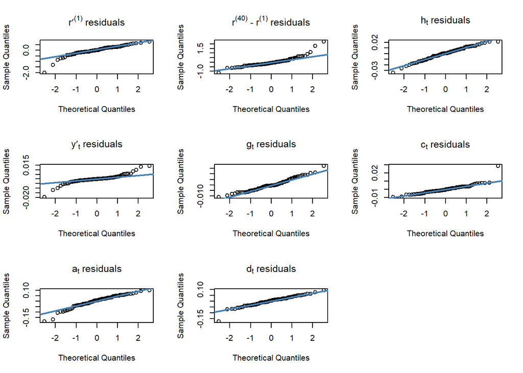

```r
train_res = residuals(train_var)

par(mfrow = c(3,3))
# zcp3m
qqnorm(train_res[,1], main = TeX("r'^{(1)}  residuals"))
qqline(train_res[,1], col = "steelblue", lwd = 2)
# zcp10y
qqnorm(train_res[,2], main = TeX("r^{(40)} - r^{(1)}  residuals"))
qqline(train_res[,2], col = "steelblue", lwd = 2)
# TeX("h_t")
qqnorm(train_res[,3], main = TeX("h_t  residuals"))
qqline(train_res[,3], col = "steelblue", lwd = 2)
# TeX("y'_t")
qqnorm(train_res[,4], main = TeX("y'_t  residuals"))
qqline(train_res[,4], col = "steelblue", lwd = 2)
# TeX("g_t")
qqnorm(train_res[,5], main = TeX("g_t  residuals"))
qqline(train_res[,5], col = "steelblue", lwd = 2)
# TeX("c_t")
qqnorm(train_res[,6], main = TeX("c_t  residuals"))
qqline(train_res[,6], col = "steelblue", lwd = 2)
# TeX("a_t")
qqnorm(train_res[,7], main = TeX("a_t  residuals"))
qqline(train_res[,7], col = "steelblue", lwd = 2)
# TeX("d_t")
qqnorm(train_res[,8], main = TeX("d_t  residuals"))
qqline(train_res[,8], col = "steelblue", lwd = 2)

# for (i in 1:length(all_var_names)) {
#     acf(train_res[,i], main = all_var_names[i])
# }
```

#### 4.3.1.3 Residuals

- Big residuals around GFC.

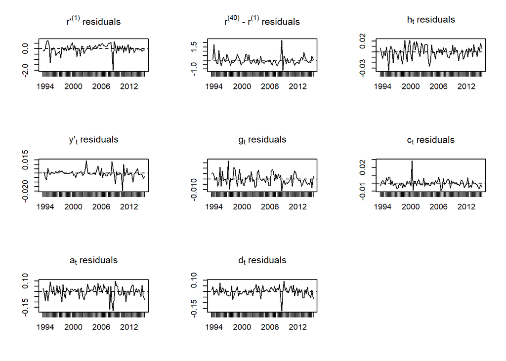

```r
par(mfrow = c(3,3))
# zcp3m
plot(all_data_original$Date[2:end_train_index], train_res[,1], "l", main = TeX("r'^{(1)}  residuals"), xlab = "", ylab = "")
abline(h = 0, lty = 2)
# zcp10y
plot(all_data_original$Date[2:end_train_index], train_res[,2], "l", main = TeX("r^{(40)} - r^{(1)}  residuals"), xlab = "", ylab = "")
abline(h = 0, lty = 2)
# TeX("h_t")
plot(all_data_original$Date[2:end_train_index], train_res[,3], "l", main = TeX("h_t  residuals"), xlab = "", ylab = "")
abline(h = 0, lty = 2)
# TeX("y'_t")
plot(all_data_original$Date[2:end_train_index], train_res[,4], "l", main = TeX("y'_t  residuals"), xlab = "", ylab = "")
abline(h = 0, lty = 2)
# TeX("g_t")
plot(all_data_original$Date[2:end_train_index], train_res[,5], "l", main = TeX("g_t  residuals"), xlab = "", ylab = "")
abline(h = 0, lty = 2)
# TeX("c_t")
plot(all_data_original$Date[2:end_train_index], train_res[,6], "l", main = TeX("c_t  residuals"), xlab = "", ylab = "")
abline(h = 0, lty = 2)
# TeX("a_t")
plot(all_data_original$Date[2:end_train_index], train_res[,7], "l", main = TeX("a_t  residuals"), xlab = "", ylab = "")
abline(h = 0, lty = 2)
# TeX("d_t")
plot(all_data_original$Date[2:end_train_index], train_res[,8], "l", main = TeX("d_t  residuals"), xlab = "", ylab = "")
abline(h = 0, lty = 2)
```

### 4.3.2 Validation on test set

```r
#########################################################
# convert forecasted variables back to its original units
# given the initial value
# returns series starting from the obs after initial value
zcp3m_inv = function (x, init) {
  # x: from forecast
  # init: initial value from original series

  # 1 it was differenced once
  diffinv(x, xi = init)[-1]
}
zcp10y_inv = function (x, zcp3) {
  # x: from forecast
  # init: initial yield from original series
  # zcp3: original series

  # 1 spread over zcp3m
  x + zcp3
}
home_value_inv = function (x, init) {
  # x: from forecast
  # init: initial index from original series

  # 1 index to growth rate
  # 2 shortened once
  output = rep(NA, length(x))
  for (i in 1:length(x)) {
    output[i] = init * exp(x[i])
    init = output[i]
  }
  return (output)
}
rental_inv = function (x, init) {
  # x: from forecast
  # init: initial index from original series

  # 1 differenced once
  diffinv(x, xi = init)[-1]
}
gdp_inv = function (x, init) {
  # x: from forecast
  # init: initial index from original series

  # 1 index to growth rate
  # 2 shortened once
  output = rep(NA, length(x))
  for (i in 1:length(x)) {
    output[i] = init * exp(x[i])
    init = output[i]
  }
  return (output)
}
cpi_inv = function (x, init) {
  # x: from forecast
  # init: initial index from original series

  # 1 index to growth rate
  # 2 shortened once
  output = rep(NA, length(x))
  for (i in 1:length(x)) {
    output[i] = init * exp(x[i])
    init = output[i]
  }
  return (output)
}
asx_inv = function (x, init) {
  # x: from forecast
  # init: initial index from original series

  # 1 index to growth rate
  # 2 shortened once
  output = rep(NA, length(x))
  for (i in 1:length(x)) {
    output[i] = init * exp(x[i])
    init = output[i]
  }
  return (output)
}
# unemploy_inv = function (x, init) {
#   # x: from forecast
#   # init: initial index from original series
#
#   # 1 differenced once
#   diffinv(x, xi = init)[-1]
# }
forex_inv = function (x, init) {
  # x: from forecast
  # init: initial index from original series

  # 1 index to growth rate
  # 2 shortened once
  output = rep(NA, length(x))
  for (i in 1:length(x)) {
    output[i] = init * exp(x[i])
    init = output[i]
  }
  return (output)
}

##################################
# testing the conversion functions
# isTRUE(all.equal(zcp3m_inv(zcp3m_stationary, all_data_original$zcp3m[1]),
#                  all_data_original$zcp3m[-1]))
# isTRUE(all.equal(zcp10y_inv(zcp10y_spread,  all_data_original$zcp3m[-1]),
#                  all_data_original$zcp10y[-1]))
# isTRUE(all.equal(home_value_inv(home_value_houses_nsw, all_data_original$home_index[1]),
#                  all_data_original$home_index[-1]))
# isTRUE(all.equal(rental_inv(rental_houses_nsw_stationary, all_data_original$rental_yield[1]),
#                  all_data_original$rental_yield[-1]))
# isTRUE(all.equal(gdp_inv(gdp, all_data_original$GDP[1]),
#                  all_data_original$GDP[-1]))
# isTRUE(all.equal(asx_inv(asx200, all_data_original$ASX200[1]),
#                  all_data_original$ASX200[-1]))
# isTRUE(all.equal(cpi_inv(cpi, all_data_original$CPI[1]),
#                  all_data_original$CPI[-1]))
# isTRUE(all.equal(forex_inv(forex, all_data_original$forex[1]),
#                  all_data_original$forex[-1]))
```

#### 4.3.2.1 Plots

- No forecast captures the COVID trends.
- Wide confidence intervals, smooth predictions.

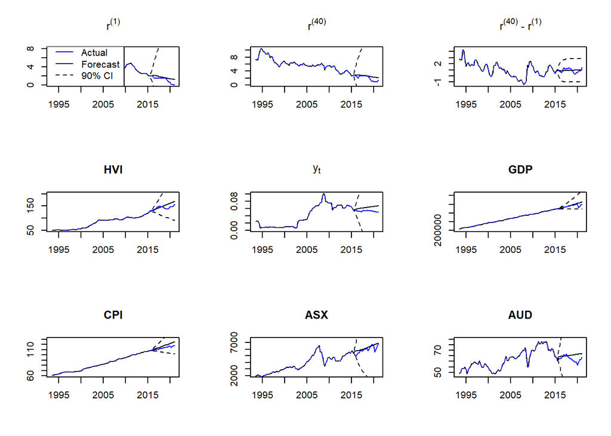

```r
##########
# forecast
test_forecast = predict(train_var, n.ahead = nrow(test), interval = "prediction", ci = 0.9)

##########################
# plots on original scales
par(mfrow = c(3,3))

############
# zcp3 month
zcp3m_forecast = zcp3m_inv(test_forecast$fcst$zcp3m_stationary[,1], all_data_original$zcp3m[max(train_index)])
plot_data_forecast = c(all_data_original$zcp3m[1+train_index], zcp3m_forecast)
zcp3m_upper = zcp3m_inv(test_forecast$fcst$zcp3m_stationary[,3], all_data_original$zcp3m[max(train_index)])
plot_data_upper = c(all_data_original$zcp3m[1+train_index], zcp3m_upper)
zcp3m_lower = zcp3m_inv(test_forecast$fcst$zcp3m_stationary[,2], all_data_original$zcp3m[max(train_index)])
plot_data_lower = c(all_data_original$zcp3m[1+train_index], zcp3m_lower)

plot(all_data_original$Date[-1], plot_data_forecast, "l", ylim = c(-0.05, 8), main = TeX("r^{(1)}"), ylab = "", xlab = "")
lines(all_data_original$Date[-1], all_data_original$zcp3m[-1], col = "blue")
lines(all_data_original$Date[-1], plot_data_upper, lty = 2)
lines(all_data_original$Date[-1], plot_data_lower, lty = 2)
legend("bottomleft", legend = c("Actual", "Forecast", "90% CI"), col = c("blue", "black", "black"), lty = c(1,1,2))


############
# zcp10 year
zcp10y_forecast = zcp10y_inv(test_forecast$fcst$zcp10y_spread[,1],  zcp3m_forecast)
plot_data_forecast = c(all_data_original$zcp10y[1+train_index], zcp10y_forecast)
plot_data_upper = zcp10y_inv(test_forecast$fcst$zcp10y_spread[,3], zcp3m_upper)
plot_data_upper = c(all_data_original$zcp10y[1+train_index], plot_data_upper)
plot_data_lower = zcp10y_inv(test_forecast$fcst$zcp10y_spread[,2], zcp3m_lower)
plot_data_lower = c(all_data_original$zcp10y[1+train_index], plot_data_lower)

plot(all_data_original$Date[-1], plot_data_forecast, "l", ylim = c(0, 10.5), main = TeX("r^{(40)}"), ylab = "", xlab = "")
lines(all_data_original$Date[-1], all_data_original$zcp10y[-1], col = "blue")
lines(all_data_original$Date[-1], plot_data_upper, lty = 2)
lines(all_data_original$Date[-1], plot_data_lower, lty = 2)


###################
# zcp10 year spread
plot_data_forecast = c(all_data[1+train_index,2], test_forecast$fcst$zcp10y_spread[,1])
plot_data_upper = c(all_data[1+train_index,2], test_forecast$fcst$zcp10y_spread[,3])
plot_data_lower = c(all_data[1+train_index,2], test_forecast$fcst$zcp10y_spread[,2])

plot(all_data_original$Date[-1], plot_data_forecast, "l", ylim = c(-1.5, 4.5), main = TeX("r^{(40)} - r^{(1)}"), ylab = "", xlab = "")
lines(all_data_original$Date[-1], all_data[-1,2], col = "blue")
lines(all_data_original$Date[-1], plot_data_upper, lty = 2)
lines(all_data_original$Date[-1], plot_data_lower, lty = 2)


############
# home index
home_index_forecast = home_value_inv(test_forecast$fcst$home_value_houses_nsw[,1], all_data_original$home_index[max(train_index)])
plot_data_forecast = c(all_data_original$home_index[1+train_index], home_index_forecast)
plot_data_upper = home_value_inv(test_forecast$fcst$home_value_houses_nsw[,3], all_data_original$home_index[max(train_index)])
plot_data_upper = c(all_data_original$home_index[1+train_index], plot_data_upper)
plot_data_lower = home_value_inv(test_forecast$fcst$home_value_houses_nsw[,2], all_data_original$home_index[max(train_index)])
plot_data_lower = c(all_data_original$home_index[1+train_index], plot_data_lower)

plot(all_data_original$Date[-1], plot_data_forecast, "l", ylim = c(50, 200), main = "HVI", ylab = "", xlab = "")
lines(all_data_original$Date[-1], all_data_original$home_index[-1], col = "blue")
lines(all_data_original$Date[-1], plot_data_upper, lty = 2)
lines(all_data_original$Date[-1], plot_data_lower, lty = 2)


##############
# rental yield
rental_forecast = rental_inv(test_forecast$fcst$rental_houses_nsw_stationary[,1], all_data_original$rental_yield[max(train_index)])
plot_data_forecast = c(all_data_original$rental_yield[1+train_index], rental_forecast)
plot_data_upper = rental_inv(test_forecast$fcst$rental_houses_nsw_stationary[,3], all_data_original$rental_yield[max(train_index)])
plot_data_upper = c(all_data_original$rental_yield[1+train_index], plot_data_upper)
plot_data_lower = rental_inv(test_forecast$fcst$rental_houses_nsw_stationary[,2], all_data_original$rental_yield[max(train_index)])
plot_data_lower = c(all_data_original$rental_yield[1+train_index], plot_data_lower)

plot(all_data_original$Date[-1], plot_data_forecast, "l", ylim = c(0, 0.1), main = TeX("y_t"), ylab = "", xlab = "")
lines(all_data_original$Date[-1], all_data_original$rental_yield[-1], col = "blue")
lines(all_data_original$Date[-1], plot_data_upper, lty = 2)
lines(all_data_original$Date[-1], plot_data_lower, lty = 2)


################
# GDP
gdp_forecast = gdp_inv(test_forecast$fcst$gdp[,1], all_data_original$GDP[max(train_index)])
plot_data_forecast = c(all_data_original$GDP[1+train_index], gdp_forecast)
plot_data_upper = gdp_inv(test_forecast$fcst$gdp[,3], all_data_original$GDP[max(train_index)])
plot_data_upper = c(all_data_original$GDP[1+train_index], plot_data_upper)
plot_data_lower = rental_inv(test_forecast$fcst$gdp[,2], all_data_original$GDP[max(train_index)])
plot_data_lower = c(all_data_original$GDP[1+train_index], plot_data_lower)

plot(all_data_original$Date[-1], plot_data_forecast, "l", ylim = c(200000, 620000), main = "GDP", ylab = "", xlab = "")
lines(all_data_original$Date[-1], all_data_original$GDP[-1], col = "blue")
lines(all_data_original$Date[-1], plot_data_upper, lty = 2)
lines(all_data_original$Date[-1], plot_data_lower, lty = 2)


#####
# CPI
cpi_forecast = cpi_inv(test_forecast$fcst$cpi[,1], all_data_original$CPI[max(train_index)])
plot_data_forecast = c(all_data_original$CPI[1+train_index], cpi_forecast)
plot_data_upper = cpi_inv(test_forecast$fcst$cpi[,3], all_data_original$CPI[max(train_index)])
plot_data_upper = c(all_data_original$CPI[1+train_index], plot_data_upper)
plot_data_lower = cpi_inv(test_forecast$fcst$cpi[,2], all_data_original$CPI[max(train_index)])
plot_data_lower = c(all_data_original$CPI[1+train_index], plot_data_lower)

plot(all_data_original$Date[-1], plot_data_forecast, "l", ylim = c(60, 130), main = "CPI", ylab = "", xlab = "")
lines(all_data_original$Date[-1], all_data_original$CPI[-1], col = "blue")
lines(all_data_original$Date[-1], plot_data_upper, lty = 2)
lines(all_data_original$Date[-1], plot_data_lower, lty = 2)


############
# S&P/ASX200
asx200_forecast = asx_inv(test_forecast$fcst$asx200[,1], all_data_original$ASX200[max(train_index)])
plot_data_forecast = c(all_data_original$ASX200[1+train_index], asx200_forecast)
plot_data_upper = asx_inv(test_forecast$fcst$asx200[,3], all_data_original$ASX200[max(train_index)])
plot_data_upper = c(all_data_original$ASX200[1+train_index], plot_data_upper)
plot_data_lower = asx_inv(test_forecast$fcst$asx200[,2], all_data_original$ASX200[max(train_index)])
plot_data_lower = c(all_data_original$ASX200[1+train_index], plot_data_lower)

plot(all_data_original$Date[-1], plot_data_forecast, "l", ylim = c(2000, 7500), main = "ASX", ylab = "", xlab = "")
lines(all_data_original$Date[-1], all_data_original$ASX200[-1], col = "blue")
lines(all_data_original$Date[-1], plot_data_upper, lty = 2)
lines(all_data_original$Date[-1], plot_data_lower, lty = 2)


##############
# unemploymnet
# unemploy_forecast = unemploy_inv(test_forecast$fcst$unemploy_nsw_stationary[,1], all_data_original$unemploy[max(train_index)])
# plot_data_forecast = c(all_data_original$unemploy[1+train_index], unemploy_forecast)
# plot_data_upper = unemploy_inv(test_forecast$fcst$unemploy_nsw_stationary[,3], all_data_original$unemploy[max(train_index)])
# plot_data_upper = c(all_data_original$unemploy[1+train_index], plot_data_upper)
# plot_data_lower = unemploy_inv(test_forecast$fcst$unemploy_nsw_stationary[,2], all_data_original$unemploy[max(train_index)])
# plot_data_lower = c(all_data_original$unemploy[1+train_index], plot_data_lower)
#
# plot(all_data_original$Date[-1], plot_data_forecast, "l", ylim = c(4.2, 7), main = all_var_names[7], ylab = "", xlab = "")
# lines(all_data_original$Date[-1], all_data_original$unemploy[-1], col = "blue")
# lines(all_data_original$Date[-1], plot_data_upper, lty = 2)
# lines(all_data_original$Date[-1], plot_data_lower, lty = 2)


###########
# AUD index
forex_forecast = forex_inv(test_forecast$fcst$forex[,1], all_data_original$forex[max(train_index)])
plot_data_forecast = c(all_data_original$forex[1+train_index], forex_forecast)
plot_data_upper = forex_inv(test_forecast$fcst$forex[,3], all_data_original$forex[max(train_index)])
plot_data_upper = c(all_data_original$forex[1+train_index], plot_data_upper)
plot_data_lower = forex_inv(test_forecast$fcst$forex[,2], all_data_original$forex[max(train_index)])
plot_data_lower = c(all_data_original$forex[1+train_index], plot_data_lower)

plot(all_data_original$Date[-1], plot_data_forecast, "l", ylim = c(47, 80), main = "AUD", ylab = "", xlab = "")
lines(all_data_original$Date[-1], all_data_original$forex[-1], col = "blue")
lines(all_data_original$Date[-1], plot_data_upper, lty = 2)
lines(all_data_original$Date[-1], plot_data_lower, lty = 2)
```